# Reproducible Research Project 2

Francisco Martín

October 2, 2018

## Synopsis

This project analyzes data from the U.S. National Oceanic and Atmospheric Administration’s (NOAA) storm database and determine the effect of major storms and weather effects on US population and economy. Summarizing, impact in population, injuries and deads, was caused by tornados and other similar evets. Otherwise, impact in economy is caused by a greater variety of fenomena, being the most important floods and droughts.

## Data Processing

This project uses data from the U.S. National Oceanic and Atmospheric Administration’s (NOAA) storm database. This data is obtained from Reproducible Research course’s page at first time, and then it is analyzed:

```r
fileName <- "data.csv.bz2"
pathName <- file.path(getwd(),fileName)
download.file("https://d396qusza40orc.cloudfront.net/repdata%2Fdata%2FStormData.csv.bz2",pathName)
dataRead <- read.csv(pathName)
head(dataRead)
```

```
##   STATE__           BGN_DATE BGN_TIME TIME_ZONE COUNTY COUNTYNAME STATE
## 1       1  4/18/1950 0:00:00     0130       CST     97     MOBILE    AL
## 2       1  4/18/1950 0:00:00     0145       CST      3    BALDWIN    AL
## 3       1  2/20/1951 0:00:00     1600       CST     57    FAYETTE    AL
## 4       1   6/8/1951 0:00:00     0900       CST     89    MADISON    AL
## 5       1 11/15/1951 0:00:00     1500       CST     43    CULLMAN    AL
## 6       1 11/15/1951 0:00:00     2000       CST     77 LAUDERDALE    AL
##    EVTYPE BGN_RANGE BGN_AZI BGN_LOCATI END_DATE END_TIME COUNTY_END
## 1 TORNADO         0                                               0
## 2 TORNADO         0                                               0
## 3 TORNADO         0                                               0
## 4 TORNADO         0                                               0
## 5 TORNADO         0                                               0
## 6 TORNADO         0                                               0
##   COUNTYENDN END_RANGE END_AZI END_LOCATI LENGTH WIDTH F MAG FATALITIES
```

[output cut: 20 more lines]

First of all, only data related to health or economic impact is going to be considered.

```r
valid_data <- c("EVTYPE", "FATALITIES", "INJURIES", "PROPDMG", "PROPDMGEXP", "CROPDMG", "CROPDMGEXP")
data_filtered <- dataRead[valid_data]
```

Columns “PROPDMGEXP” and “CROPDMGEXP” refers to cost in exponential value. This columns shows economic impact in a combination of letters and numbers. In example, 100 can appear as “H”, “h” or “2”. The list of posible characters is the following:

```r
unique(data_filtered$PROPDMGEXP)
```

```
##  [1] K M   B m + 0 5 6 ? 4 2 3 h 7 H - 1 8
## Levels:  - ? + 0 1 2 3 4 5 6 7 8 B h H K m M
```

```r
unique(data_filtered$CROPDMGEXP)
```

```
## [1]   M K m B ? 0 k 2
## Levels:  ? 0 2 B k K m M
```

This values will be renamed in two new columns called “GOOD_PROPEXP” and “GOOD_CROPEXP”

```r
data_filtered$GOOD_PROPEXP[data_filtered$PROPDMGEXP == "+" | data_filtered$PROPDMGEXP == "-" | data_filtered$PROPDMGEXP == "?" | data_filtered$PROPDMGEXP == ""] <- 0
data_filtered$GOOD_PROPEXP[data_filtered$PROPDMGEXP == "0"] <- 1
data_filtered$GOOD_PROPEXP[data_filtered$PROPDMGEXP == "1"] <- 10
data_filtered$GOOD_PROPEXP[data_filtered$PROPDMGEXP == "H" | data_filtered$PROPDMGEXP == "h" | data_filtered$PROPDMGEXP == "2" ] <- 100
data_filtered$GOOD_PROPEXP[data_filtered$PROPDMGEXP == "K" | data_filtered$PROPDMGEXP == "3" ] <- 1000
data_filtered$GOOD_PROPEXP[data_filtered$PROPDMGEXP == "4"] <- 10000
data_filtered$GOOD_PROPEXP[data_filtered$PROPDMGEXP == "5"] <- 100000
data_filtered$GOOD_PROPEXP[data_filtered$PROPDMGEXP == "M" | data_filtered$PROPDMGEXP == "m" | data_filtered$PROPDMGEXP == "6" ] <- 1000000
data_filtered$GOOD_PROPEXP[data_filtered$PROPDMGEXP == "7"] <- 10000000
data_filtered$GOOD_PROPEXP[data_filtered$PROPDMGEXP == "8"] <- 100000000
data_filtered$GOOD_PROPEXP[data_filtered$PROPDMGEXP == "B"] <- 1000000000

data_filtered$GOOD_CROPEXP[data_filtered$CROPDMGEXP == "?" | data_filtered$CROPDMGEXP == "" ] <- 0
data_filtered$GOOD_CROPEXP[data_filtered$CROPDMGEXP == "0" ] <- 1
data_filtered$GOOD_CROPEXP[data_filtered$CROPDMGEXP == "2" ] <- 100
data_filtered$GOOD_CROPEXP[data_filtered$CROPDMGEXP == "k" | data_filtered$CROPDMGEXP == "K" ] <- 1000
data_filtered$GOOD_CROPEXP[data_filtered$CROPDMGEXP == "m" | data_filtered$CROPDMGEXP == "M" ] <- 1000000
data_filtered$GOOD_CROPEXP[data_filtered$CROPDMGEXP == "B" ] <- 1000000000
```

Finally, total economic damage is given by the multiplication of columns “PROPDMG” and “GOOD_PROPEXP” for property damages and the multiplication of columns “CROPDMG” and “GOOD_CROPEXP” for crop damages. This values will be saved in two new columns called “COST_PROP” and “COST_CROP”

```r
data_filtered$COST_PROP <- data_filtered$PROPDMG * data_filtered$GOOD_PROPEXP
data_filtered$COST_CROP <- data_filtered$CROPDMG * data_filtered$GOOD_CROPEXP
```

In order to plot correctly, it is useful to calculate total fatalities, injuries, property damage and crop damage per different event:

```r
fatalities <- aggregate(FATALITIES~EVTYPE, data_filtered, sum)
injuries <- aggregate(INJURIES~EVTYPE, data_filtered, sum)
prop_damage <- aggregate(COST_PROP~EVTYPE, data_filtered, sum)
crop_damage <- aggregate(COST_CROP~EVTYPE, data_filtered, sum)
```

And now data is ready to be plotted and evaluated evaluated.

## Results

### Population Health analysis

First of all let’s look at health analysis. There are two measures here, fatalities and injuries. As there are more than 980 different events, only top-10 is going to be analyzed.

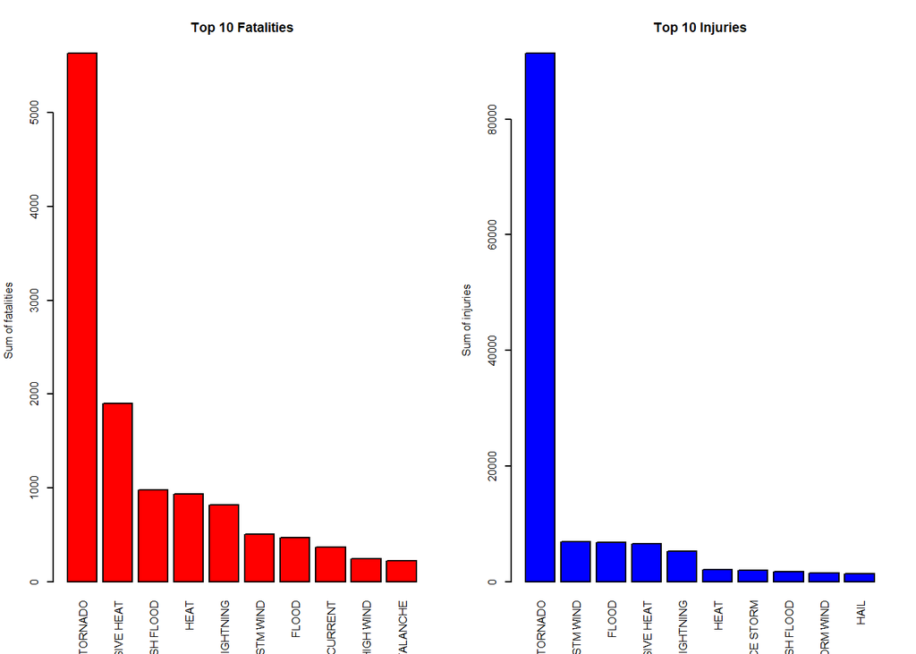

```r
top10_fatalities <- fatalities[order(-fatalities$FATALITIES), ][1:10, ]
top10_injuries <- injuries[order(-injuries$INJURIES), ][1:10, ]

par(mfrow = c(1, 2), cex = 0.5)
barplot(top10_fatalities$FATALITIES, las = 3, names.arg = top10_fatalities$EVTYPE, main = "Top 10 Fatalities", ylab = "Sum of fatalities", col = "red")
barplot(top10_injuries$INJURIES, las = 3, names.arg = top10_injuries$EVTYPE, main = "Top 10 Injuries", ylab = "Sum of injuries", col = "blue")
```

It can be seen that tornadoes are by far the most dangerous event for U.S. people. They causes the most injuries and fatalities.

### Economic Health analysis

Weather events also have an impact on economic health. Here there are also two measures, Property damage and Crop damage. Let’s look at the top-10 events which has a greater impact on U.S. economy:

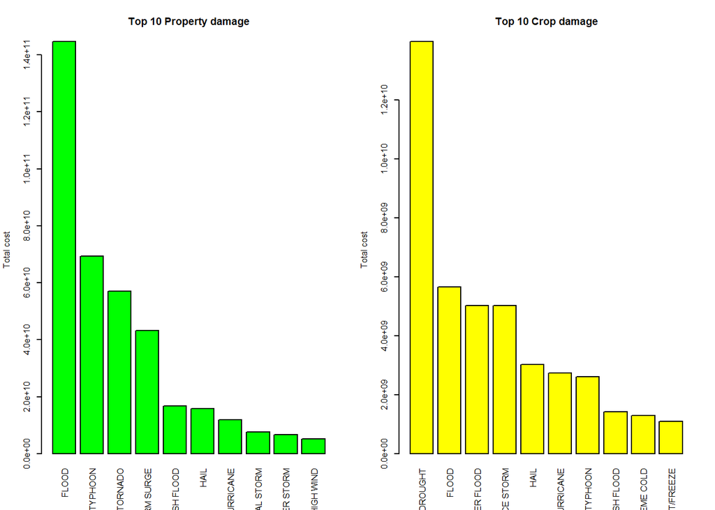

```r
top10_Prop <- prop_damage[order(-prop_damage$COST_PROP), ][1:10, ]
top10_Crop <- crop_damage[order(-crop_damage$COST_CROP), ][1:10, ]

par(mfrow = c(1, 2), cex = 0.5)
barplot(top10_Prop$COST_PROP, las = 3, names.arg = top10_Prop$EVTYPE, main = "Top 10 Property damage", ylab = "Total cost", col = "green")
barplot(top10_Crop$COST_CROP, las = 3, names.arg = top10_Crop$EVTYPE, main = "Top 10 Crop damage", ylab = "Total cost", col = "yellow")
```

As we can see, Flood generates the maximun property damage, but Crop damage is domined by Drought.

## Conclusion

In this project we have evaluated impact of weather events on population health and also in economic health in U.S. As a result, we have obtained that largest population health impact is caused by tornadoes, but in economic health both Flood and Drought are the dominants. Other events such as extreme head can be neutralized by social education, but they are quite less important in terms of population and economic health.